# University of Bristol OpenSAFELY Best Practice

Tom Palmer, Elsie Horne, Venexia Walker

22 February 2022

## Introduction

The following is intended as a set of tips for users of the OpenSAFELY system at the University of Bristol.

## Best practice guide

### Study definition

#### Reproducibile dummy data

- To ensure the dummy data system generates exactly the same data every time you run it, set a random number generator seed at the top of the `study_definition.py` file

  ```python
  import numpy as np
  np.random.seed(123456) # change this number to one for which your scripts successfully run on the dummy data
  ```

#### File formats

- Use `.feather` files for outputs from the cohortextractor, so specify an action in your `project.yaml` as follows

  ```yaml
  generate_study_population:
    run: cohortextractor:latest generate_cohort --study-definition study_definition --output-format feather
   needs:
    - design
    outputs:
      highly_sensitive:
        cohort: output/input.feather
  ```

- Use the **arrow** package to read `.feather` files into R

  ```r
  arrow::read_feather(file = file.path("output", "input.feather"))
  ```

  - The `col_select` argument can be used to read in just the columns you need
- Start each project with a preprocessing action that formats `.feather` files and outputs (gzipped) `.rds` files which can be saved with `readr::write_rds()`

  ```r
  readr::write_rds(object, file.path("output", "mydata.rds"), compress = "gz")
  ```

### R code

#### File formats

  ```r
  object <- readr::read_rds(file.path("output", "mydata.rds"))
  readr::write_rds(object, file.path("output", "mydata.rds"), compress = "gz")
  ```

- All `.rds` files should all be classified as `highly_sensitive` in actions, as they cannot be opened on the results server and therefore cannot be reviewed or released.
- `readr::write_rds` does not compress files by default. It is recommended that you compress .rds files using the argument `compress = "gz"`.
- Use `file.path` to construct file paths that are reproducible across operating systems.

#### Supported packages

- The R packages (and their version number) which are installed in the OpenSAFELY R Docker container are listed [here](https://github.com/opensafely-core/r-docker/blob/master/packages.csv)
- To request a new package, which should be on CRAN, open a new issue [here](https://github.com/opensafely-core/r-docker/issues), including the link to its CRAN webpage

#### RStudio project

- Define your repo as an RStudio project in RStudio as follows
  - File | New Project…

[figure not shown]

  - Existing Directory

[figure not shown]

  - Then find your repo
  - This will create a `.Rproj` file at the top level of your repo
  - Commit the file into your repo
  - Now you can double click the `.Rproj` file to open the repo in RStudio, so you can work on your R scripts more conveniently

### Outputs for release

All outputs for release should be classified as `moderately_sensitive` in actions. OpenSAFELY does not permit information relating to between 1 and less than 5 individuals to be released. Redaction functions are available from other users to help you prepare your output.

#### Tables

- Use `readr::write_csv()` to save `.csv` files that will be sent to output checkers (this is about twice as fast as `utils::write.csv()` and does not write row names).

  ```r
  readr::write_csv(object, file = file.path("output", "mydata.csv"))
  ```

- Do not save outputs to subdirectories of the `output` folder, otherwise running the study definition on GitHub Actions will probably fail with an error message such as

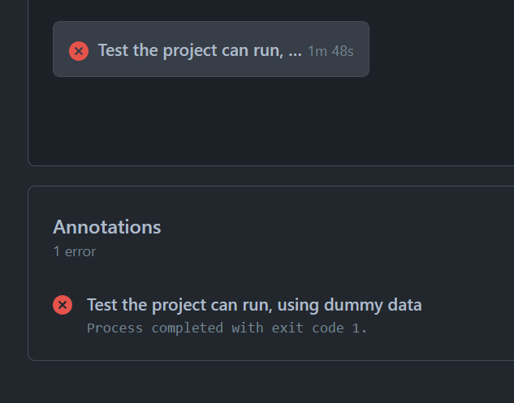

  ```
  Error in file(file, ifelse(append, "a", "w")) :
     cannot open the connection
   Calls: write.csv -> eval.parent -> eval -> eval -> write.table -> file
   In addition: Warning message:
   In file(file, ifelse(append, "a", "w")) :
     cannot open file '/workspace/output/descriptive/tables/table1.csv': No such file or directory
   Backtrace:
   1: file(file, ifelse(append, "a", "w"))
   2: write.table(table1_all$table_body, here::here("output", "descriptive",
   3: eval(expr, p)
   4: eval(expr, p)
   5: eval.parent(Call)
   6: write.csv(table1_all$table_body, here::here("output", "descriptive",

  Error: Process completed with exit code 1.
  ```

#### Figures

- Use `.svg` for figure outputs that will be sent to output checkers
- Where applicable (e.g., histograms), start the *x*-axis at 5 instead of 0 to ensure low counts are not exported

#### Releasing output

- Ensure your outputs are in the correct formats
  - `.csv` (not `.rds` or `.Rdata`) for tables of data
  - `.txt` or `.html` if you want to view them in L4
- Ensure your outputs are marked as `moderately_sensitive` in your `project.yaml`
- To release an output, please complete the ‘Output files for review’ section of [this form](https://docs.opensafely.org/documents/OpenSAFELY_Output_Review_Form_15_11_21.docx) and email to your assigned Bristol L4 access person
- Bristol L4 access people will check the output on the server on your behalf, complete the rest of the form (including files locations), and email to datarelease@opensafely.org for final approval

### Miscellaneous

- Text files should end with a newline character (i.e., a blank line)
  - If you see the following red icon at the end of a file on GitHub, simply press `↵ Enter` at the end of the file (i.e., in this case after the `Catalog`), resave, commit, and the red icon should be gone

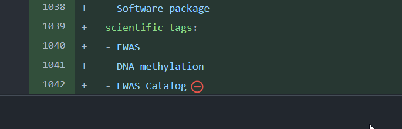

- Python and R versions
  - The versions of Python and R in their respective OpenSAFELY Docker containers are (as of 1<sup>st</sup> December 2021):
    - Python 3.8.10
    - R 4.0.2
  - The Python and R code run within their respective Docker containers. Hence the version of Python and R used to run your analyses are the versions of Python and R in these Docker containers and *not* the versions of Python and R on your computer
  - To see the Python version number insert in your `study_definition.py`

    ```python
    import sys
    print(sys.implementation.version)
    ```

  - To see the R version number insert into one of your R analysis scripts

    ```r
    print(R.version.string)
    ```